# HW 4 - Hilde Younce

**Honor Pledge:** On my honor as a student, I have neither given nor received unauthorized aid on this assignment.

```r
library(brms)
library(ggplot2)
library(dplyr)
sales_data <- read.csv('sales-ds6040.csv')
```

```r
head(sales_data)
```

```
##        sales food       con     neur store
## 1  1.3638206    0 0.2165529 1.290224     0
## 2 -1.1197467    1 0.2165529 1.290224     0
## 3 -0.1801406    0 0.2165529 1.290224     0
## 4 -2.2823338    1 0.2165529 1.290224     0
## 5  0.6733045    0 0.2165529 1.290224     0
## 6 -2.3499185    1 0.2165529 1.290224     0
```

### Problem Statement

We aim to investigate how regional store sales are influenced by the neuroticism and conscientiousness scores of store managers. Specifically, we seek to understand differences in sales between food and coffee orders. To achieve this, we will implement a Bayesian hierarchical model that accounts for clustering by store ID and incorporates a linear regression framework to explore these sales differences. Our goal is to uncover insights into the role of manager personality in driving sales performance and identify stores expected to perform well even in the absence of highly neurotic or conscientious managers.

### Approach:

We will employ a Bayesian hierarchical model, focusing on a random slope mixed-effects design. This approach is ideal for our analysis as it accounts for clustering by store while allowing variability in sales trends across stores. Specifically, we will model sales as the outcome, with predictors for food versus coffee transactions, standardized neuroticism and conscientiousness scores, and interactions between these predictors. By incorporating store-level random effects, our model effectively captures differences in sales behavior across locations.

Using this hierarchical structure, we achieve the flexibility of performing store-specific regressions while leveraging the full dataset. This approach enables us to identify patterns and trends in sales across the region, offering a cohesive view of how manager personality traits impact store performance.

The model is as follows:

$$Sales_{ij} = \beta_{0j} + \beta_{1j} * Food + \beta_{2j} * Con +
\beta_{3j}*Neur + \beta_{4j} * Con * Food + \beta_{5j}*Neur*Food +
\epsilon_{i}$$

Which is equivalent to:

$$y_{ij} = \beta_{0j} + \beta_{1j}x_{1ij} + \beta_{2j}*x_{2ij} +
\beta_{3j}*x_{3ij} + \beta_{4j}*x_{4ij} + \beta_{4j}*x_{5ij} +
\epsilon_i$$

$$\epsilon_i \sim N(0, \sigma^2)$$
$$\beta_{0j} \sim N(\mu_{\beta_0}, \sigma_0^2)$$
$$\beta_{1j} \sim N(\mu_{\beta_1}, \sigma_1^2)$$
Where:

$Sales_{ij}$ - Sales for month $i$ in store $j$

$\beta_{0j}$ - Random intercept for store $j$

$\beta_{1j}$ - Effect of food transactions for store $j$

$\beta_{2j}$ - Effect of conscientiousness on coffee sales for store $j$

$\beta_{3j}$ - Effect of neuroticism on coffee sales for store $j$

$\beta_{4j}$ - Difference in $\beta_{2j}$ effect on food sales for store $j$

$\beta_{5j}$ - Difference in $\beta_{3j}$ effect on food sales for store $j$

$\epsilon_{i}$ - Residual error

### Prior Selection and Rationale:

Our priors for this model are:

$$\mu_{\beta_0}, \mu_{\beta_1} \sim N(0,10)$$

For the sigma values, we are using a Half-Cauchy distribution. Again we will choose uninformative hyperparamters. We set 0 as the mean since we are using Half-Cauchy, and thus only looking at positive values. Our scale parameter is 2, which favors smaller variances and makes the distribution centered closer to zero.

### Findings:

```r
# brms model
formula <- bf(sales ~ con + neur + food + con*food + neur*food + (food|store))
priors <- c(
  set_prior("normal(0, 10)", class = "b"),
  set_prior("cauchy(0,2)", class = "sd")
)
model <- brm(formula, data=sales_data, prior=priors, refresh=0, silent=2)
```

[output not shown]

```r
summary(model)
```

```
##  Family: gaussian
##   Links: mu = identity; sigma = identity
## Formula: sales ~ con + neur + food + con * food + neur * food + (food | store)
##    Data: sales_data (Number of observations: 480)
##   Draws: 4 chains, each with iter = 2000; warmup = 1000; thin = 1;
##          total post-warmup draws = 4000
##
## Multilevel Hyperparameters:
## ~store (Number of levels: 20)
##                     Estimate Est.Error l-95% CI u-95% CI Rhat Bulk_ESS Tail_ESS
## sd(Intercept)           1.27      0.25     0.87     1.87 1.00     1802     2131
## sd(food)                0.85      0.20     0.53     1.30 1.00     2043     2197
## cor(Intercept,food)     0.19      0.26    -0.34     0.65 1.00     1940     2447
##
## Regression Coefficients:
##           Estimate Est.Error l-95% CI u-95% CI Rhat Bulk_ESS Tail_ESS
## Intercept     0.51      0.33    -0.12     1.14 1.00     1448     1975
## con           0.34      0.49    -0.62     1.33 1.00     1835     2167
## neur         -0.40      0.30    -1.02     0.20 1.00     1902     2343
## food         -0.84      0.24    -1.31    -0.38 1.00     2422     2776
## con:food      1.00      0.35     0.30     1.70 1.00     2631     2406
## neur:food     0.12      0.22    -0.32     0.55 1.00     2451     2252
##
## Further Distributional Parameters:
##       Estimate Est.Error l-95% CI u-95% CI Rhat Bulk_ESS Tail_ESS
## sigma     1.02      0.03     0.95     1.08 1.00     4436     3068
##
## Draws were sampled using sampling(NUTS). For each parameter, Bulk_ESS
## and Tail_ESS are effective sample size measures, and Rhat is the potential
## scale reduction factor on split chains (at convergence, Rhat = 1).
```

How does conscientiousness and neuroticism impact the sales of coffee and food, and are coffee and  
food impacted differently?

To understand how store manager personality traits influence food and coffee sales, we interpret the regression coefficients from our model.

Coffee sales:

- The coefficient for conscientiousness is 0.34, indicating that coffee sales increase by 0.34 transactions for every one-unit increase in conscientiousness.
- Conversely, the coefficient for neuroticism is -0.41, meaning coffee sales decrease by 0.41 transactions for every one-unit increase in neuroticism.
- These results suggest that conscientiousness has a small positive impact on coffee sales, while neuroticism has a slightly negative effect.

Food sales:

The interaction terms con * food and neur * food represent the offset from the coffee coefficients. To interpret their impact on food transactions, we sum the coffee coefficients and their corresponding interaction terms:

- For conscientiousness: 1.01+0.34=1.35. This indicates that food sales increase by 1.35 transactions for every one-unit increase in conscientiousness.
- For neuroticism: 0.11−0.41=−0.30. This shows that food sales decrease by 0.30 transactions for every one-unit increase in neuroticism.

Overall, conscientiousness has a significant positive impact on food sales, while neuroticism has a small negative effect.

Comparing food and coffee sales:

In summary, conscientiousness appears to have a more substantial positive influence on food sales compared to coffee, while neuroticism generally has a negative impact on both types of sales but with less differentiation.

Once you control for the personality characteristics of the store managers, what stores should be  
performing well? (i.e. the rest of the employees might be great, but the store manager might be bringing sales down)

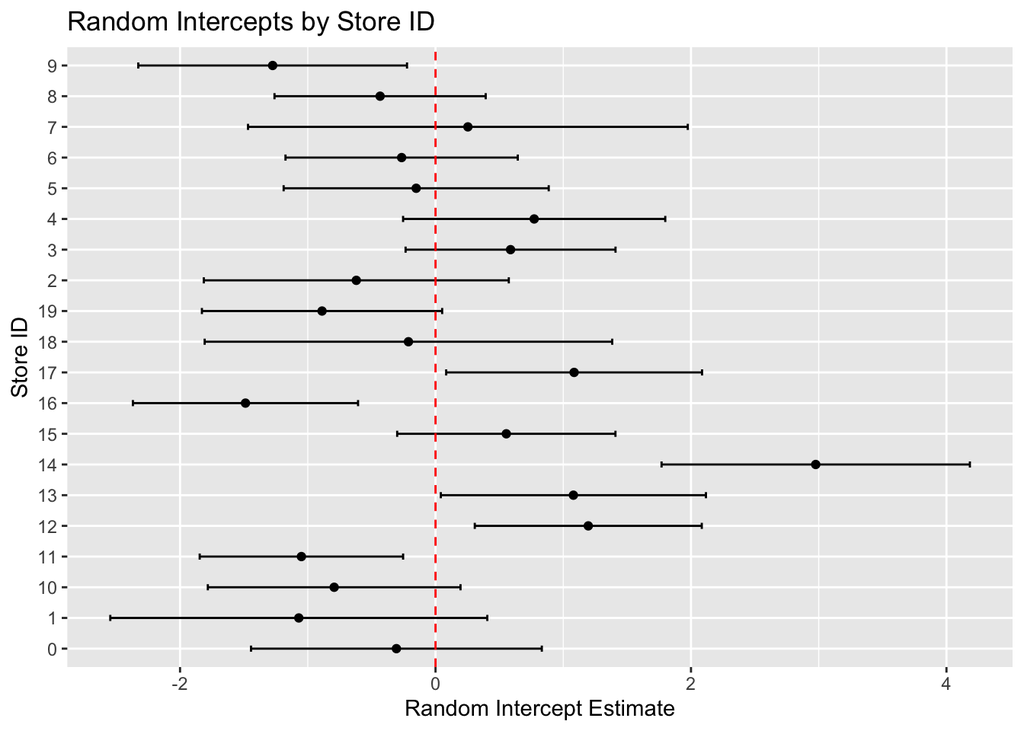

```r
ranef_data <- ranef(model)$store
intercepts <- ranef_data[, , "Intercept"]

intercepts_df <- as.data.frame(intercepts)
intercepts_df <- intercepts_df %>%
  mutate(store = rownames(intercepts_df),
         lower = Estimate - 1.96 * Est.Error,
         upper = Estimate + 1.96 * Est.Error)

ggplot(intercepts_df, aes(x = Estimate, y = store)) +
  geom_point() +
  geom_errorbarh(aes(xmin = lower, xmax = upper), height = 0.2) +
  geom_vline(xintercept = 0, linetype = "dashed", color = "red") +
  labs(
    title = "Random Intercepts by Store ID",
    x = "Random Intercept Estimate",
    y = "Store ID")
```

In this plot, we are measuring the random intercept estimates and confidence intervals for each store. These random intercepts represent deviations in store performance from the average sales, after controlling for the fixed effects (including manager personality characteristics). Thus, stores with the highest random intercept estimates are expected to perform well when accounting for store manager personality, and low random intercept estimates indicate a store is not performing well in comparison to average sales. Based on our results, we see that stores 14, 12, 13, and 17 are performing best. On the other hand, stores 16, 9, and 11 are performing worst in comparison to average sales.

### Diagnostics

**Trace Plots:**

```
## No divergences to plot.
```

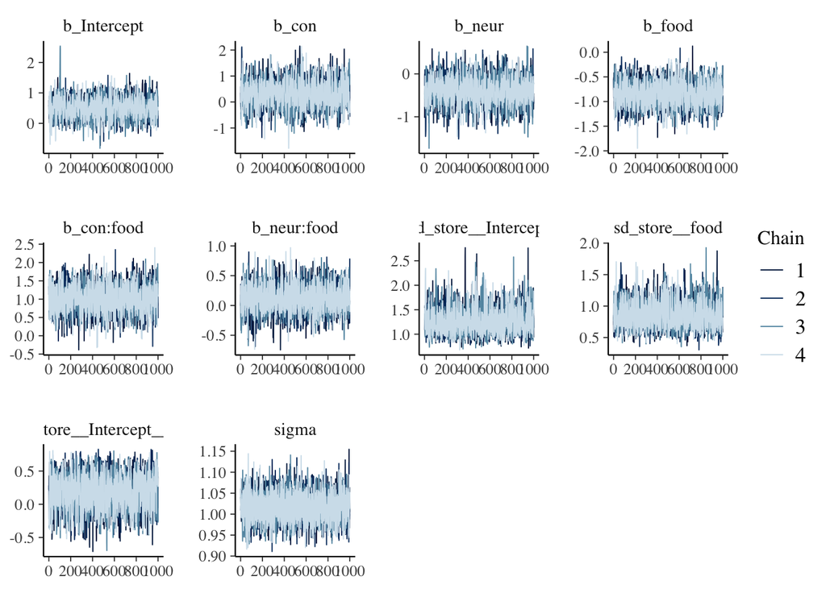

```r
mcmc_plot(model, type = "trace")
```

**Density Plots:**

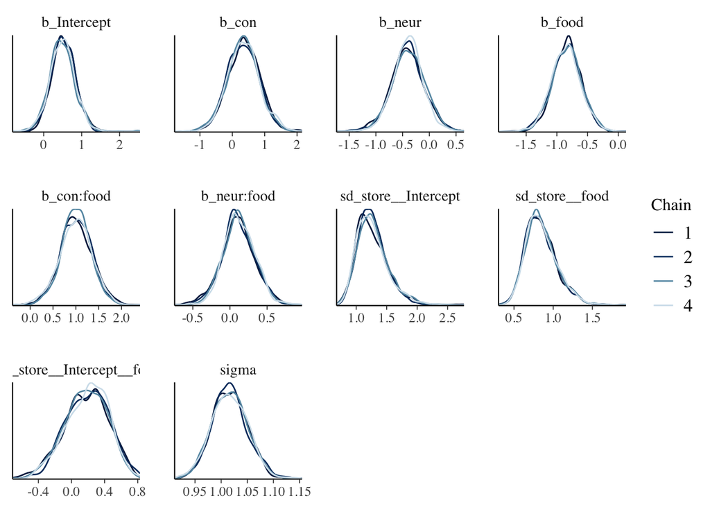

```r
mcmc_plot(model, type = "dens_overlay")
```

**Coefficient Plots:**

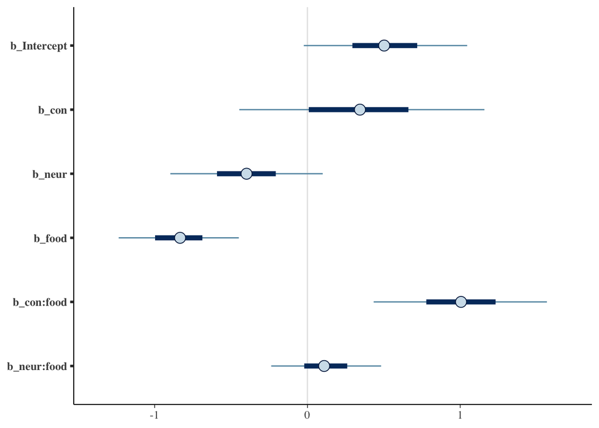

[figure not shown]

```r
mcmc_plot(model, type = "intervals", pars = "b_")
```